# STAT 420: Homework 09

Kwon, YoungJu

2018-07-02

# Directions

Students are encouraged to work together on homework using the discussion boards. However, sharing, copying, or providing any part of a homework solution or code is an infraction of the University’s rules on academic integrity. Any violation will be punished as severely as possible.

- Your assignment must be submitted through Coursera. You are required to upload one `.zip` file, named `hw09_yourNetID.zip`, which contains:
  - Your RMarkdown file which should be saved as `hw09_yourNetID.Rmd`. For example `hw09_dalpiaz2.Rmd`.
  - The result of knitting your RMarkdown file as `hw09_yourNetID.html`. For example `hw09_dalpiaz2.html`.
  - Any outside data provided as a `.csv` file used for the homework.
  - This will roughly match the `.zip` provided.
- Your resulting `.html` file will be considered a “report” which is the material that will determine the majority of your grade. Be sure to visibly include all `R` code and output that is relevant to answering the exercises. (You do not need to include irrelevant code you tried that resulted in error or did not answer the question correctly.)
- You are granted an unlimited number of submissions, but only the last submission *before* the deadline will be viewed and graded.
- If you use this `.Rmd` file as a template, be sure to remove the quotation, directions section, and consider removing `eval = FALSE` from any code chunks provided (if you would like to run that code as part of your assignment).
- Your `.Rmd` file should be written such that, when stored in a folder with any data you are asked to import, it will knit properly without modification. If your `.zip` file is organized properly, this should not be an issue.
- Unless otherwise stated, you may use `R` for each of the exercises.
- Be sure to read each exercise carefully!
- Include your name and NetID in the final document, not only in your filenames.

# Assignment

## Exercise 1 (Writing Functions)

**(a)** Write a function that takes as input a model object (variable) fit via `lm()` and outputs a fitted versus residuals plot. Also, create arguments `pointcol` and `linecol`, which control the point and line colors, respectively. Code the plot to add a horizontal line at $y = 0$, and label the $x$-axis “Fitted” and the $y$-axis “Residuals”.

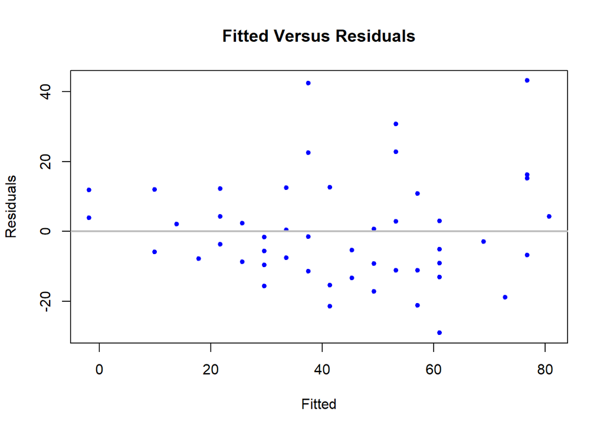

```r
sim_lm = lm(dist~speed, data=cars)
fitVsRes <- function(model, pointcol="grey", linecol="darkorange"){
  fit_val = fitted(model)
  res_val = resid(model)
  plot(fit_val, res_val, col=pointcol, pch=20, xlab="Fitted", ylab="Residuals", main="Fitted Versus Residuals")
  abline(h=0, col=linecol, lwd=2)
}
fitVsRes(sim_lm, "blue", "grey")
```

*(b)** Write a function that takes as input a model fit via `lm()` and plots a Normal Q-Q plot of the residuals. Also, create arguments `pointcol` and `linecol`, which control the point and line colors, respectively. Code the plot to add the line from `qqline()`.

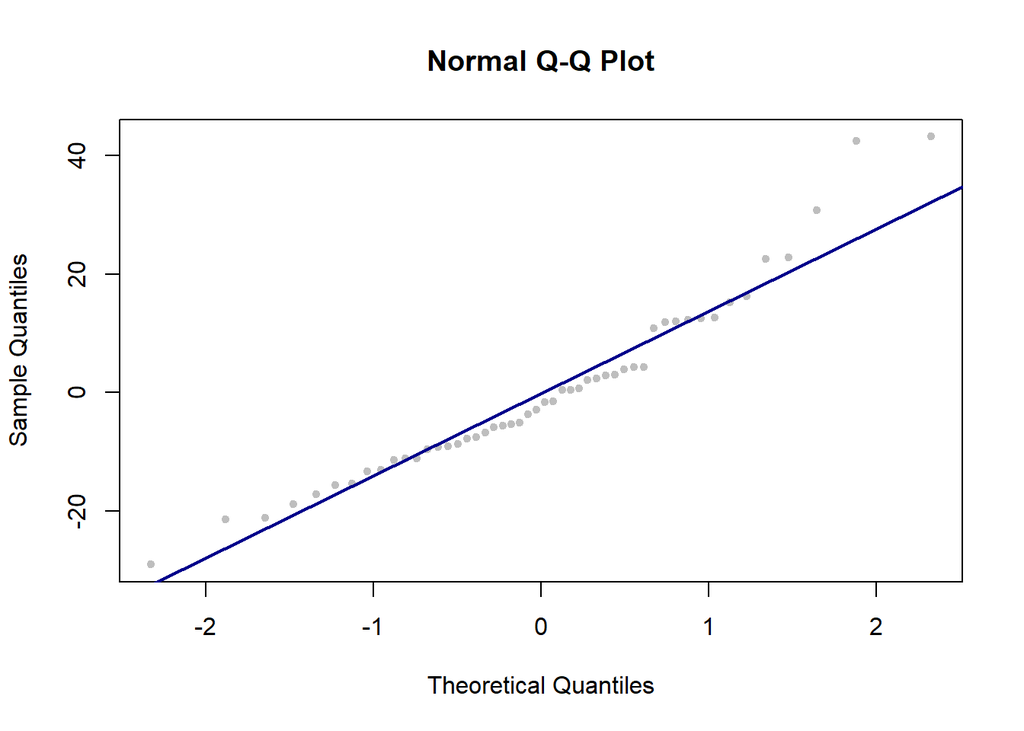

```r
qqPlot <- function(model, pointcol="grey", linecol="darkblue"){
  qqnorm(resid(sim_lm), col = pointcol, main ="Normal Q-Q Plot", pch=20)
  qqline(resid(sim_lm), col = linecol, lwd=2)
}
qqPlot(sim_lm)
```

**(c)** Test your two functions above on the `test_fit` model. For both functions, specify point and line colors that are not black.

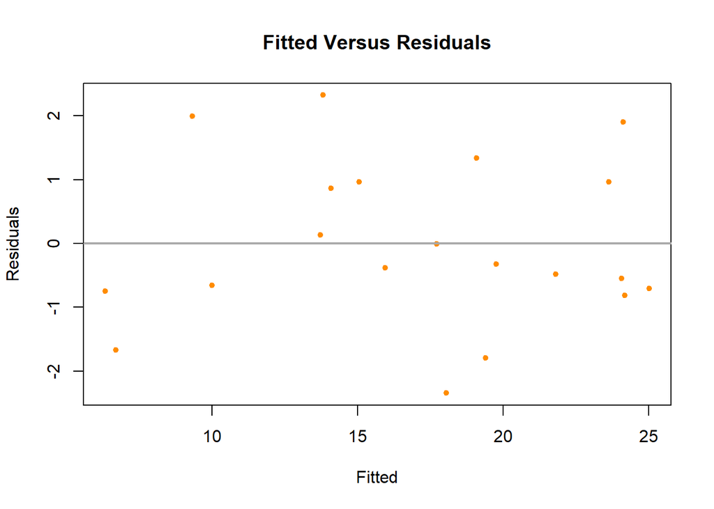

```r
set.seed(42)
test_data = data.frame(x = runif(n = 20, min = 0, max = 10),
                       y = rep(x = 0, times = 20))
test_data$y = with(test_data, 5 + 2 * x + rnorm(n = 20))
test_fit = lm(y ~ x, data = test_data)

fitVsRes(test_fit, pointcol="darkorange", linecol ="darkgrey")
```

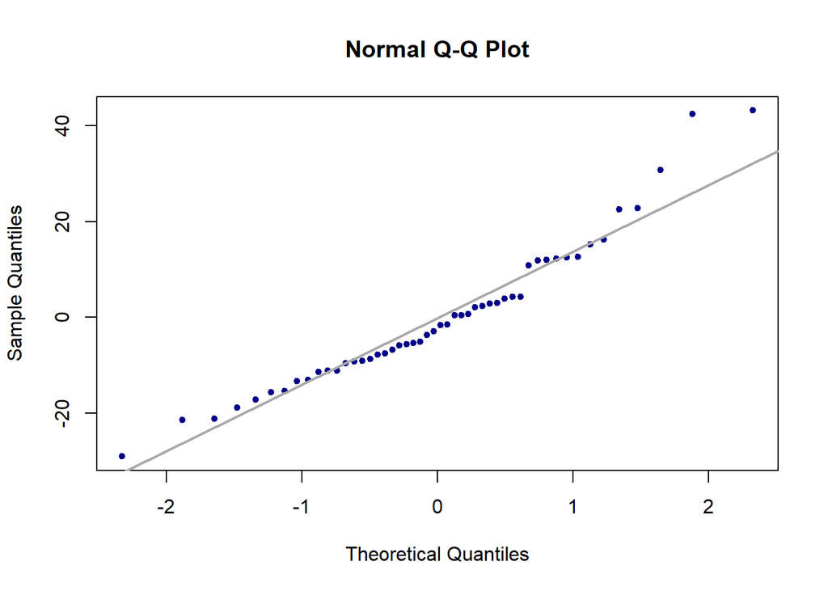

```r
qqPlot(test_fit, pointcol="darkblue", linecol ="darkgrey")
```

## Exercise 2 (Swiss Fertility Data)

For this exercise we will use the `swiss` data, which can be found in the `faraway` package. After loading the `faraway` package, use `?swiss` to learn about this dataset.

```r
library(faraway)
```

**(a)** Fit an additive multiple regression model with `Fertility` as the response and the remaining variables in the `swiss` dataset as predictors. Output the estimated regression coefficients for this model.

```r
sw_lm = lm(Fertility~., data=swiss)
coef(sw_lm)
```

```
##      (Intercept)      Agriculture      Examination        Education
##          66.9152          -0.1721          -0.2580          -0.8709
##         Catholic Infant.Mortality
##           0.1041           1.0770
```

**(b)** Check the constant variance assumption for this model. Do you feel it has been violated? Justify your answer.

```r
library(lmtest)
# Breusch-Pagan Test
# H0: Homoscedasticity: The errors have constant variance.
# H1: Hetroscedasticity: The errors have non-constan variance.

bptest(sw_lm)
```

```
##
##  studentized Breusch-Pagan test
##
## data:  sw_lm
## BP = 5.9, df = 5, p-value = 0.3
```

Since p-value of bp-test has far higher value than 0.05, we fail to reject Null hypothesis.

**(c)** Check the normality assumption for this model. Do you feel it has been violated? Justify your answer.

```r
# Shapiro-Wilk Test
# H0: Data are sampled from normal
# H1: Data are not sampled from normal
shapiro.test(resid(sw_lm))
```

```
##
##  Shapiro-Wilk normality test
##
## data:  resid(sw_lm)
## W = 0.99, p-value = 0.9
```

As p-value of shapiro-wilk normality test shows high value, we fail to reject null hypothesis, which is that residual values are noramlly distributed.

**(d)** Check for any high leverage observations. Report any observations you determine to have high leverage.

```r
# High leverage data is a data point that could have a large influence when fitting the model.

X = cbind(rep(1,length(swiss[2])), swiss[-1])
X= as.matrix(X)
p_mat = X%*%solve(t(X)%*%X)%*%t(X)
p_mean = mean(diag(p_mat))
h_leverage= diag(p_mat)[diag(p_mat)>2*p_mean]
hatvalues(sw_lm)[hatvalues(sw_lm) >2*mean(hatvalues(sw_lm))]
```

```
##    La Vallee V. De Geneve
##       0.3512       0.4558
```

**(e)** Check for any influential observations. Report any observations you determine to be influential.

```r
# Outliers are datapoints with large residuals
out_resid = rstandard(sw_lm)[abs(rstandard(sw_lm))>2]
influential = cooks.distance(sw_lm)>4/length(cooks.distance(sw_lm))
print(influential)
```

```
##   Courtelary     Delemont Franches-Mnt      Moutier   Neuveville   Porrentruy
##        FALSE        FALSE        FALSE        FALSE        FALSE         TRUE
##        Broye        Glane      Gruyere       Sarine      Veveyse        Aigle
##        FALSE        FALSE        FALSE        FALSE        FALSE        FALSE
##      Aubonne     Avenches     Cossonay    Echallens     Grandson     Lausanne
##        FALSE        FALSE        FALSE        FALSE        FALSE        FALSE
##    La Vallee       Lavaux       Morges       Moudon        Nyone         Orbe
##        FALSE        FALSE        FALSE        FALSE        FALSE        FALSE
##         Oron      Payerne Paysd'enhaut        Rolle        Vevey      Yverdon
##        FALSE        FALSE        FALSE        FALSE        FALSE        FALSE
##      Conthey    Entremont       Herens     Martigwy      Monthey   St Maurice
##        FALSE        FALSE        FALSE        FALSE        FALSE        FALSE
##       Sierre         Sion       Boudry La Chauxdfnd     Le Locle    Neuchatel
##         TRUE        FALSE        FALSE        FALSE        FALSE         TRUE
##   Val de Ruz ValdeTravers V. De Geneve  Rive Droite  Rive Gauche
##        FALSE        FALSE        FALSE         TRUE         TRUE
```

**(f)** Refit the additive multiple regression model without any points you identified as influential. Compare the coefficients of this fitted model to the previously fitted model.

```r
swiss_re = swiss[-influential,]
sw_mod_lm = lm(Fertility~., data=swiss_re)
coef(sw_mod_lm)-coef(sw_lm)
```

```
##      (Intercept)      Agriculture      Examination        Education
##        -1.578827         0.017702         0.055513        -0.004506
##         Catholic Infant.Mortality
##         0.004962        -0.026523
```

**(g)** Create a data frame that stores the observations that were “removed” because they were influential. Use the two models you have fit to make predictions with these observations. Comment on the difference between these two sets of predictions.

```r
new_data = swiss[influential,]
predict(sw_lm, newdata = new_data)-new_data$Fertility
```

```
##  Porrentruy      Sierre   Neuchatel Rive Droite Rive Gauche
##      14.400     -15.321     -10.881       9.662      15.274
```

```r
predict(sw_mod_lm, newdata = new_data)-new_data$Fertility
```

```
##  Porrentruy      Sierre   Neuchatel Rive Droite Rive Gauche
##      13.658     -15.188     -10.875       9.433      15.054
```

## Exercise 3 (Concrete, Again)

Return to the concrete data from the ANOVA homework. Recall, we chose the additive model. Now that we see how ANOVA can be framed as a linear model, check for any violation of assumptions for this model.

```r
concrete = read.csv("concrete.csv")
concrete$curing = as.factor(concrete$curing)

conc_lm = lm(strength~., data=concrete)
bptest(conc_lm)
```

```
##
##  studentized Breusch-Pagan test
##
## data:  conc_lm
## BP = 5.8, df = 5, p-value = 0.3
```

It has constant vairance.

```r
shapiro.test(resid(conc_lm))
```

```
##
##  Shapiro-Wilk normality test
##
## data:  resid(conc_lm)
## W = 0.99, p-value = 0.9
```

Its residual follow normality.

```r
sum(cooks.distance(conc_lm)>4/length(resid(conc_lm)))
```

```
## [1] 3
```

There are some influential data.

```r
conc_mod_lm = lm(strength~., data= concrete[cooks.distance(conc_lm)<=4/length(resid(conc_lm)),])
coef(conc_lm)-coef(conc_mod_lm)
```

```
## (Intercept)     curing2     curing3     cementB     cementC     cementD
##   3.846e-01   3.365e-01   3.109e-15   5.556e-02  -1.097e+00  -4.968e-01
```

However, there is no significant difference between the models with or without influential data.

## Exercise 4 (Why Bother?)

**Why** do we care about violations of assumptions? One key reason is that the distributions of the parameters that we have used are all reliant on these assumptions. When the assumptions are violated, the distributional results are not correct, so our tests are garbage. **Garbage In, Garbage Out!**

Consider the following setup that we will use for the remainder of the exercise. We choose a sample size of 50.

```r
n = 50
set.seed(1)
x_1 = runif(n, 0, 10)
x_2 = runif(n, -5, 5)
```

Consider the model,

$$Y = 2 + 1 x_1 + 0 x_2 + \epsilon.$$

That is,

- $\beta_0$ = 2
- $\beta_1$ = 1
- $\beta_2$ = 0

We now simulate `y_1` in a manner that does not violate any assumptions, which we will verify. In this case $\epsilon \sim N(0, 1).$

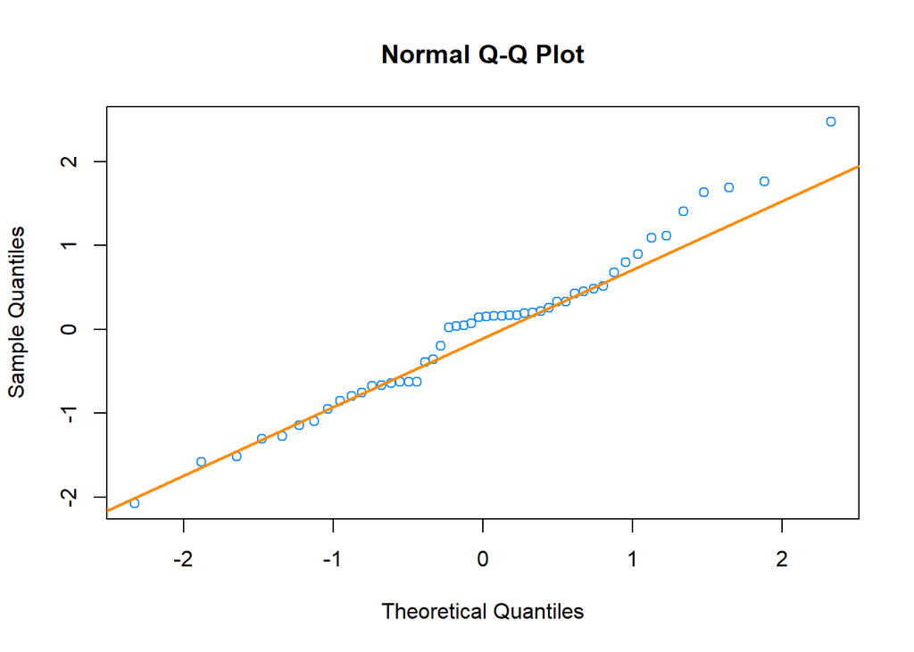

```r
y_1 = 2 + x_1 + 0 * x_2 + rnorm(n = n, mean = 0, sd = 1)
fit_1 = lm(y_1 ~ x_1 + x_2)
qqnorm(resid(fit_1), col = "dodgerblue")
qqline(resid(fit_1), col = "darkorange", lwd = 2)
```

```r
shapiro.test(resid(fit_1))
```

```
##
##  Shapiro-Wilk normality test
##
## data:  resid(fit_1)
## W = 0.98, p-value = 0.6
```

Then, we simulate `y_2` in a manner that **does** violate assumptions, which we again verify. In this case $\epsilon \sim N(0, \sigma = |x_2|).$

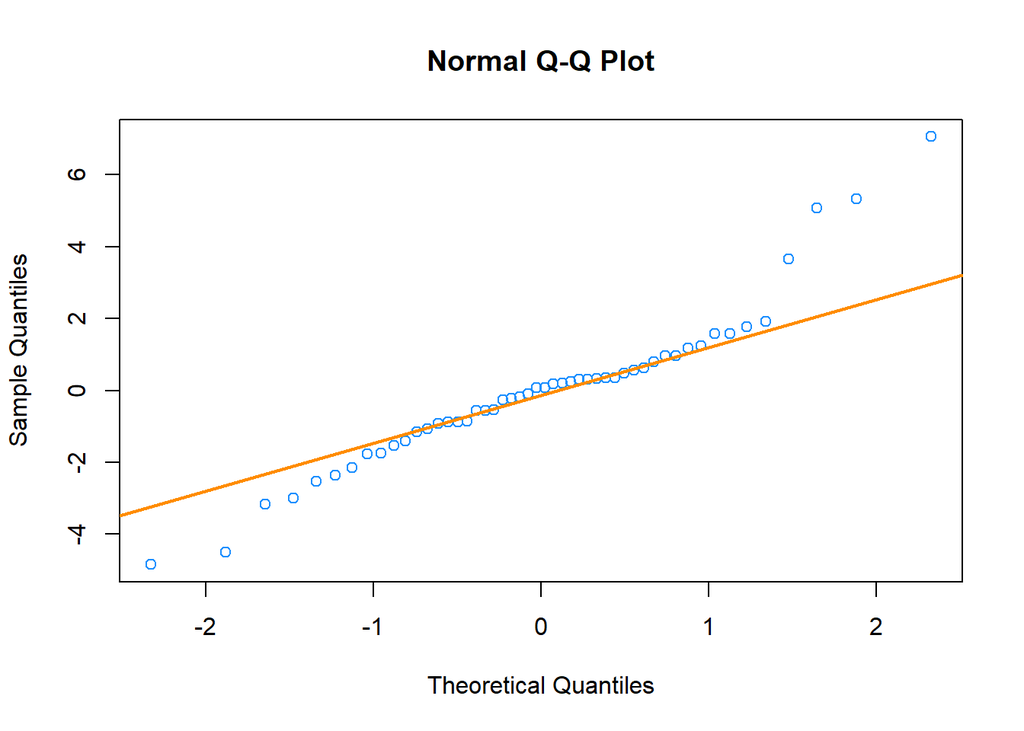

```r
y_2 = 2 + x_1 + 0 * x_2 + rnorm(n = n, mean = 0, sd = abs(x_2))
fit_2 = lm(y_2 ~ x_1 + x_2)
qqnorm(resid(fit_2), col = "dodgerblue")
qqline(resid(fit_2), col = "darkorange", lwd = 2)
```

```r
shapiro.test(resid(fit_2))
```

```
##
##  Shapiro-Wilk normality test
##
## data:  resid(fit_2)
## W = 0.93, p-value = 0.005
```

**(a)** Use the following code after changing `birthday` to your birthday.

```r
num_sims = 1000
p_val_1 = rep(0, num_sims)
p_val_2 = rep(0, num_sims)
birthday = 19920502
set.seed(birthday)
p_val_1 = as.numeric(p_val_1)
str(p_val_1)
```

```
##  num [1:1000] 0 0 0 0 0 0 0 0 0 0 ...
```

Repeat the above process of generating `y_1` and `y_2` as defined above, and fit models with each as the response `1000` times. Each time, store the p-value for testing,

$$\beta_2 = 0,$$

using both models, in the appropriate variables defined above. (You do not need to use a data frame as we have in the past. Although, feel free to modify the code to instead use a data frame.)

```r
simulating = function(num_sim = 1000){
  pvals=data.frame(fit1=1:num_sim, fit2=1:num_sim)
  for(i in 1:num_sim){
    y_1 = 2+ x_1+ 0*x_2 +rnorm(n=n, mean=0, sd=1)
    y_2 = 2+ x_1+ 0*x_2 +rnorm(n=n, mean=0, sd=abs(x_2))
    fit_1 = lm(y_1~x_1+ x_2)
    fit_2 = lm(y_2~x_1+ x_2)
    pvals[i,1]= shapiro.test(resid(fit_1))$p.val
    pvals[i,2]= shapiro.test(resid(fit_2))$p.val
  }
  return(pvals)
}
pvals = simulating(num_sims)
```

**(b)** What proportion of the `p_val_1` values are less than 0.05? Less than 0.10? What proportion of the `p_val_2` values are less than 0.05? Less than 0.10? Briefly explain these results.

```r
sum(pvals[,1]<0.05)/num_sims
```

```
## [1] 0.055
```

```r
sum(pvals[,1]<0.1)/num_sims
```

```
## [1] 0.111
```

```r
sum(pvals[,2]<0.05)/num_sims
```

```
## [1] 0.495
```

```r
sum(pvals[,2]<0.1)/num_sims
```

```
## [1] 0.624
```

As expected, model 2 does not follow normality since we set sd of errors as absolute value of x_2. Thus, model 2 is highly likely to violate normality assumption.

# STAT 420: Homework 09

Kwon, YoungJu

2018-07-02

# Directions

Students are encouraged to work together on homework using the discussion boards. However, sharing, copying, or providing any part of a homework solution or code is an infraction of the University’s rules on academic integrity. Any violation will be punished as severely as possible.

- Your assignment must be submitted through Coursera. You are required to upload one `.zip` file, named `hw09_yourNetID.zip`, which contains:
  - Your RMarkdown file which should be saved as `hw09_yourNetID.Rmd`. For example `hw09_dalpiaz2.Rmd`.
  - The result of knitting your RMarkdown file as `hw09_yourNetID.html`. For example `hw09_dalpiaz2.html`.
  - Any outside data provided as a `.csv` file used for the homework.
  - This will roughly match the `.zip` provided.
- Your resulting `.html` file will be considered a “report” which is the material that will determine the majority of your grade. Be sure to visibly include all `R` code and output that is relevant to answering the exercises. (You do not need to include irrelevant code you tried that resulted in error or did not answer the question correctly.)
- You are granted an unlimited number of submissions, but only the last submission *before* the deadline will be viewed and graded.
- If you use this `.Rmd` file as a template, be sure to remove the quotation, directions section, and consider removing `eval = FALSE` from any code chunks provided (if you would like to run that code as part of your assignment).
- Your `.Rmd` file should be written such that, when stored in a folder with any data you are asked to import, it will knit properly without modification. If your `.zip` file is organized properly, this should not be an issue.
- Unless otherwise stated, you may use `R` for each of the exercises.
- Be sure to read each exercise carefully!
- Include your name and NetID in the final document, not only in your filenames.

# Assignment

## Exercise 1 (Writing Functions)

**(a)** Write a function that takes as input a model object (variable) fit via `lm()` and outputs a fitted versus residuals plot. Also, create arguments `pointcol` and `linecol`, which control the point and line colors, respectively. Code the plot to add a horizontal line at $y = 0$, and label the $x$-axis “Fitted” and the $y$-axis “Residuals”.

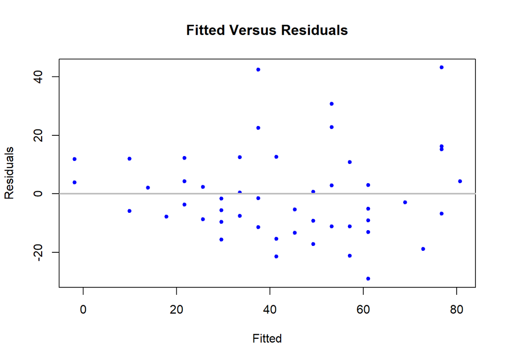

```r
sim_lm = lm(dist~speed, data=cars)
fitVsRes <- function(model, pointcol="grey", linecol="darkorange"){
  fit_val = fitted(model)
  res_val = resid(model)
  plot(fit_val, res_val, col=pointcol, pch=20, xlab="Fitted", ylab="Residuals", main="Fitted Versus Residuals")
  abline(h=0, col=linecol, lwd=2)
}
fitVsRes(sim_lm, "blue", "grey")
```

*(b)** Write a function that takes as input a model fit via `lm()` and plots a Normal Q-Q plot of the residuals. Also, create arguments `pointcol` and `linecol`, which control the point and line colors, respectively. Code the plot to add the line from `qqline()`.

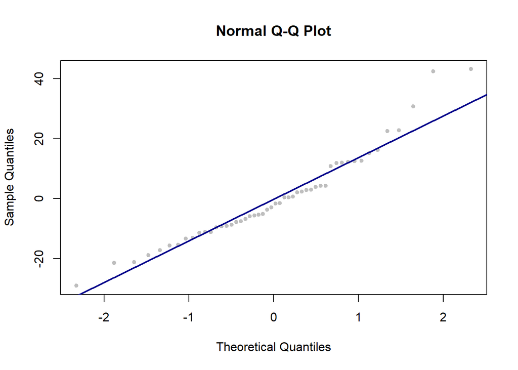

```r
qqPlot <- function(model, pointcol="grey", linecol="darkblue"){
  qqnorm(resid(sim_lm), col = pointcol, main ="Normal Q-Q Plot", pch=20)
  qqline(resid(sim_lm), col = linecol, lwd=2)
}
qqPlot(sim_lm)
```

**(c)** Test your two functions above on the `test_fit` model. For both functions, specify point and line colors that are not black.

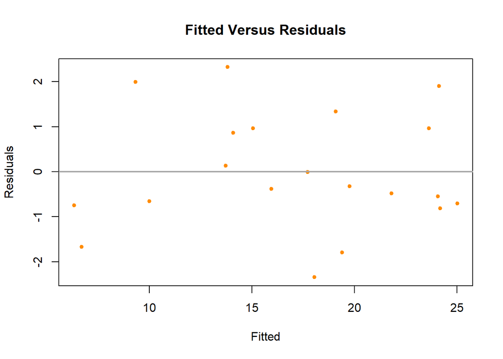

```r
set.seed(42)
test_data = data.frame(x = runif(n = 20, min = 0, max = 10),
                       y = rep(x = 0, times = 20))
test_data$y = with(test_data, 5 + 2 * x + rnorm(n = 20))
test_fit = lm(y ~ x, data = test_data)

fitVsRes(test_fit, pointcol="darkorange", linecol ="darkgrey")
```

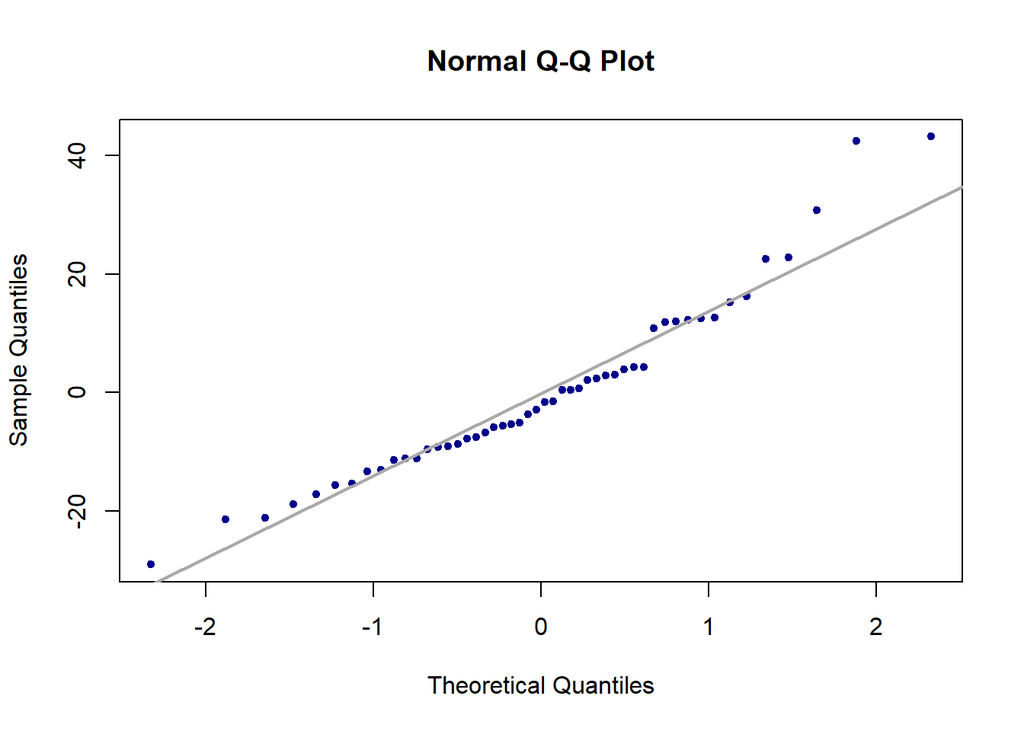

```r
qqPlot(test_fit, pointcol="darkblue", linecol ="darkgrey")
```

## Exercise 2 (Swiss Fertility Data)

For this exercise we will use the `swiss` data, which can be found in the `faraway` package. After loading the `faraway` package, use `?swiss` to learn about this dataset.

```r
library(faraway)
```

**(a)** Fit an additive multiple regression model with `Fertility` as the response and the remaining variables in the `swiss` dataset as predictors. Output the estimated regression coefficients for this model.

```r
sw_lm = lm(Fertility~., data=swiss)
coef(sw_lm)
```

```
##      (Intercept)      Agriculture      Examination        Education
##          66.9152          -0.1721          -0.2580          -0.8709
##         Catholic Infant.Mortality
##           0.1041           1.0770
```

**(b)** Check the constant variance assumption for this model. Do you feel it has been violated? Justify your answer.

```r
library(lmtest)
# Breusch-Pagan Test
# H0: Homoscedasticity: The errors have constant variance.
# H1: Hetroscedasticity: The errors have non-constan variance.

bptest(sw_lm)
```

```
##
##  studentized Breusch-Pagan test
##
## data:  sw_lm
## BP = 5.9, df = 5, p-value = 0.3
```

Since p-value of bp-test has far higher value than 0.05, we fail to reject Null hypothesis.

**(c)** Check the normality assumption for this model. Do you feel it has been violated? Justify your answer.

```r
# Shapiro-Wilk Test
# H0: Data are sampled from normal
# H1: Data are not sampled from normal
shapiro.test(resid(sw_lm))
```

```
##
##  Shapiro-Wilk normality test
##
## data:  resid(sw_lm)
## W = 0.99, p-value = 0.9
```

As p-value of shapiro-wilk normality test shows high value, we fail to reject null hypothesis, which is that residual values are noramlly distributed.

**(d)** Check for any high leverage observations. Report any observations you determine to have high leverage.

```r
# High leverage data is a data point that could have a large influence when fitting the model.

X = cbind(rep(1,length(swiss[2])), swiss[-1])
X= as.matrix(X)
p_mat = X%*%solve(t(X)%*%X)%*%t(X)
p_mean = mean(diag(p_mat))
h_leverage= diag(p_mat)[diag(p_mat)>2*p_mean]
hatvalues(sw_lm)[hatvalues(sw_lm) >2*mean(hatvalues(sw_lm))]
```

```
##    La Vallee V. De Geneve
##       0.3512       0.4558
```

**(e)** Check for any influential observations. Report any observations you determine to be influential.

```r
# Outliers are datapoints with large residuals
out_resid = rstandard(sw_lm)[abs(rstandard(sw_lm))>2]
influential = cooks.distance(sw_lm)>4/length(cooks.distance(sw_lm))
print(influential)
```

```
##   Courtelary     Delemont Franches-Mnt      Moutier   Neuveville   Porrentruy
##        FALSE        FALSE        FALSE        FALSE        FALSE         TRUE
##        Broye        Glane      Gruyere       Sarine      Veveyse        Aigle
##        FALSE        FALSE        FALSE        FALSE        FALSE        FALSE
##      Aubonne     Avenches     Cossonay    Echallens     Grandson     Lausanne
##        FALSE        FALSE        FALSE        FALSE        FALSE        FALSE
##    La Vallee       Lavaux       Morges       Moudon        Nyone         Orbe
##        FALSE        FALSE        FALSE        FALSE        FALSE        FALSE
##         Oron      Payerne Paysd'enhaut        Rolle        Vevey      Yverdon
##        FALSE        FALSE        FALSE        FALSE        FALSE        FALSE
##      Conthey    Entremont       Herens     Martigwy      Monthey   St Maurice
##        FALSE        FALSE        FALSE        FALSE        FALSE        FALSE
##       Sierre         Sion       Boudry La Chauxdfnd     Le Locle    Neuchatel
##         TRUE        FALSE        FALSE        FALSE        FALSE         TRUE
##   Val de Ruz ValdeTravers V. De Geneve  Rive Droite  Rive Gauche
##        FALSE        FALSE        FALSE         TRUE         TRUE
```

**(f)** Refit the additive multiple regression model without any points you identified as influential. Compare the coefficients of this fitted model to the previously fitted model.

```r
swiss_re = swiss[-influential,]
sw_mod_lm = lm(Fertility~., data=swiss_re)
coef(sw_mod_lm)-coef(sw_lm)
```

```
##      (Intercept)      Agriculture      Examination        Education
##        -1.578827         0.017702         0.055513        -0.004506
##         Catholic Infant.Mortality
##         0.004962        -0.026523
```

**(g)** Create a data frame that stores the observations that were “removed” because they were influential. Use the two models you have fit to make predictions with these observations. Comment on the difference between these two sets of predictions.

```r
new_data = swiss[influential,]
predict(sw_lm, newdata = new_data)-new_data$Fertility
```

```
##  Porrentruy      Sierre   Neuchatel Rive Droite Rive Gauche
##      14.400     -15.321     -10.881       9.662      15.274
```

```r
predict(sw_mod_lm, newdata = new_data)-new_data$Fertility
```

```
##  Porrentruy      Sierre   Neuchatel Rive Droite Rive Gauche
##      13.658     -15.188     -10.875       9.433      15.054
```

## Exercise 3 (Concrete, Again)

Return to the concrete data from the ANOVA homework. Recall, we chose the additive model. Now that we see how ANOVA can be framed as a linear model, check for any violation of assumptions for this model.

```r
concrete = read.csv("concrete.csv")
concrete$curing = as.factor(concrete$curing)

conc_lm = lm(strength~., data=concrete)
bptest(conc_lm)
```

```
##
##  studentized Breusch-Pagan test
##
## data:  conc_lm
## BP = 5.8, df = 5, p-value = 0.3
```

It has constant vairance.

```r
shapiro.test(resid(conc_lm))
```

```
##
##  Shapiro-Wilk normality test
##
## data:  resid(conc_lm)
## W = 0.99, p-value = 0.9
```

Its residual follow normality.

```r
sum(cooks.distance(conc_lm)>4/length(resid(conc_lm)))
```

```
## [1] 3
```

There are some influential data.

```r
conc_mod_lm = lm(strength~., data= concrete[cooks.distance(conc_lm)<=4/length(resid(conc_lm)),])
coef(conc_lm)-coef(conc_mod_lm)
```

```
## (Intercept)     curing2     curing3     cementB     cementC     cementD
##   3.846e-01   3.365e-01   3.109e-15   5.556e-02  -1.097e+00  -4.968e-01
```

However, there is no significant difference between the models with or without influential data.

## Exercise 4 (Why Bother?)

**Why** do we care about violations of assumptions? One key reason is that the distributions of the parameters that we have used are all reliant on these assumptions. When the assumptions are violated, the distributional results are not correct, so our tests are garbage. **Garbage In, Garbage Out!**

Consider the following setup that we will use for the remainder of the exercise. We choose a sample size of 50.

```r
n = 50
set.seed(1)
x_1 = runif(n, 0, 10)
x_2 = runif(n, -5, 5)
```

Consider the model,

$$Y = 2 + 1 x_1 + 0 x_2 + \epsilon.$$

That is,

- $\beta_0$ = 2
- $\beta_1$ = 1
- $\beta_2$ = 0

We now simulate `y_1` in a manner that does not violate any assumptions, which we will verify. In this case $\epsilon \sim N(0, 1).$

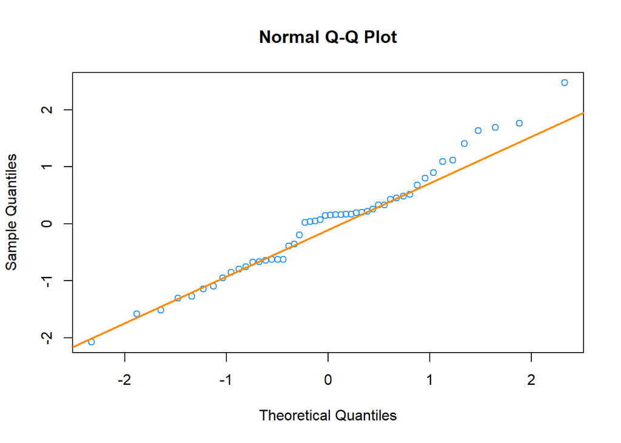

```r
y_1 = 2 + x_1 + 0 * x_2 + rnorm(n = n, mean = 0, sd = 1)
fit_1 = lm(y_1 ~ x_1 + x_2)
qqnorm(resid(fit_1), col = "dodgerblue")
qqline(resid(fit_1), col = "darkorange", lwd = 2)
```

```r
shapiro.test(resid(fit_1))
```

```
##
##  Shapiro-Wilk normality test
##
## data:  resid(fit_1)
## W = 0.98, p-value = 0.6
```

Then, we simulate `y_2` in a manner that **does** violate assumptions, which we again verify. In this case $\epsilon \sim N(0, \sigma = |x_2|).$

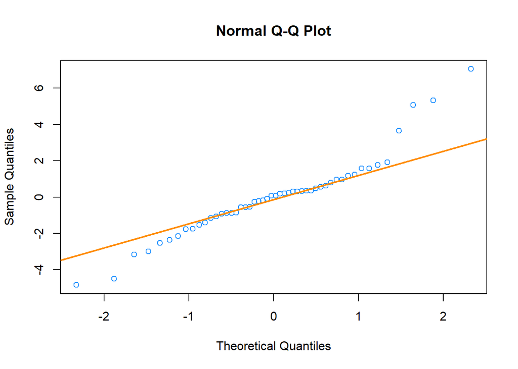

```r
y_2 = 2 + x_1 + 0 * x_2 + rnorm(n = n, mean = 0, sd = abs(x_2))
fit_2 = lm(y_2 ~ x_1 + x_2)
qqnorm(resid(fit_2), col = "dodgerblue")
qqline(resid(fit_2), col = "darkorange", lwd = 2)
```

```r
shapiro.test(resid(fit_2))
```

```
##
##  Shapiro-Wilk normality test
##
## data:  resid(fit_2)
## W = 0.93, p-value = 0.005
```

**(a)** Use the following code after changing `birthday` to your birthday.

```r
num_sims = 1000
p_val_1 = rep(0, num_sims)
p_val_2 = rep(0, num_sims)
birthday = 19920502
set.seed(birthday)
p_val_1 = as.numeric(p_val_1)
str(p_val_1)
```

```
##  num [1:1000] 0 0 0 0 0 0 0 0 0 0 ...
```

Repeat the above process of generating `y_1` and `y_2` as defined above, and fit models with each as the response `1000` times. Each time, store the p-value for testing,

$$\beta_2 = 0,$$

using both models, in the appropriate variables defined above. (You do not need to use a data frame as we have in the past. Although, feel free to modify the code to instead use a data frame.)

```r
simulating = function(num_sim = 1000){
  pvals=data.frame(fit1=1:num_sim, fit2=1:num_sim)
  for(i in 1:num_sim){
    y_1 = 2+ x_1+ 0*x_2 +rnorm(n=n, mean=0, sd=1)
    y_2 = 2+ x_1+ 0*x_2 +rnorm(n=n, mean=0, sd=abs(x_2))
    fit_1 = lm(y_1~x_1+ x_2)
    fit_2 = lm(y_2~x_1+ x_2)
    pvals[i,1]= shapiro.test(resid(fit_1))$p.val
    pvals[i,2]= shapiro.test(resid(fit_2))$p.val
  }
  return(pvals)
}
pvals = simulating(num_sims)
```

**(b)** What proportion of the `p_val_1` values are less than 0.05? Less than 0.10? What proportion of the `p_val_2` values are less than 0.05? Less than 0.10? Briefly explain these results.

```r
sum(pvals[,1]<0.05)/num_sims
```

```
## [1] 0.055
```

```r
sum(pvals[,1]<0.1)/num_sims
```

```
## [1] 0.111
```

```r
sum(pvals[,2]<0.05)/num_sims
```

```
## [1] 0.495
```

```r
sum(pvals[,2]<0.1)/num_sims
```

```
## [1] 0.624
```

As expected, model 2 does not follow normality since we set sd of errors as absolute value of x_2. Thus, model 2 is highly likely to violate normality assumption.